# Risk Factor Analysis

## Outcome Variable

**Outcome Variable:** ever_stunted

## Predictor Variables

**Intervention Variable:** birthwtXexclfeed6

**Adjustment Set:**

- arm
- sex
- W_mage
- meducyrs
- feducyrs
- hhwealth_quart
- hfoodsec
- vagbrth
- W_nrooms
- W_nchldlt5
- brthmon
- W_parity
- impfloor
- impsan
- safeh20
- delta_W_mage
- delta_meducyrs
- delta_feducyrs
- delta_hhwealth_quart
- delta_hfoodsec
- delta_vagbrth
- delta_W_nrooms
- delta_W_nchldlt5
- delta_brthmon
- delta_W_parity
- delta_impfloor
- delta_impsan
- delta_safeh20

## Stratifying Variables

The analysis was stratified on these variable(s):

- agecat
- studyid
- country

## Data Summary

| agecat | studyid | country | birthwtXexclfeed6 | ever_stunted | n_cell | n |
| --- | --- | --- | --- | --- | --- | --- |
| 6-24 months | ki0047075b-MAL-ED | BANGLADESH | Normal or high birthweight X EBF | 0 | 17 | 153 |
| 6-24 months | ki0047075b-MAL-ED | BANGLADESH | Normal or high birthweight X EBF | 1 | 18 | 153 |
| 6-24 months | ki0047075b-MAL-ED | BANGLADESH | Low birth weight X EBF | 0 | 2 | 153 |
| 6-24 months | ki0047075b-MAL-ED | BANGLADESH | Low birth weight X EBF | 1 | 1 | 153 |
| 6-24 months | ki0047075b-MAL-ED | BANGLADESH | Normal or high birthweight X No EBF | 0 | 62 | 153 |
| 6-24 months | ki0047075b-MAL-ED | BANGLADESH | Normal or high birthweight X No EBF | 1 | 44 | 153 |
| 6-24 months | ki0047075b-MAL-ED | BANGLADESH | Low birth weight X No EBF | 0 | 6 | 153 |
| 6-24 months | ki0047075b-MAL-ED | BANGLADESH | Low birth weight X No EBF | 1 | 3 | 153 |
| 6-24 months | ki0047075b-MAL-ED | BRAZIL | Normal or high birthweight X EBF | 0 | 12 | 168 |
| 6-24 months | ki0047075b-MAL-ED | BRAZIL | Normal or high birthweight X EBF | 1 | 1 | 168 |
| 6-24 months | ki0047075b-MAL-ED | BRAZIL | Low birth weight X EBF | 0 | 0 | 168 |
| 6-24 months | ki0047075b-MAL-ED | BRAZIL | Low birth weight X EBF | 1 | 0 | 168 |
| 6-24 months | ki0047075b-MAL-ED | BRAZIL | Normal or high birthweight X No EBF | 0 | 145 | 168 |
| 6-24 months | ki0047075b-MAL-ED | BRAZIL | Normal or high birthweight X No EBF | 1 | 8 | 168 |
| 6-24 months | ki0047075b-MAL-ED | BRAZIL | Low birth weight X No EBF | 0 | 2 | 168 |
| 6-24 months | ki0047075b-MAL-ED | BRAZIL | Low birth weight X No EBF | 1 | 0 | 168 |
| 6-24 months | ki0047075b-MAL-ED | INDIA | Normal or high birthweight X EBF | 0 | 2 | 149 |
| 6-24 months | ki0047075b-MAL-ED | INDIA | Normal or high birthweight X EBF | 1 | 1 | 149 |
| 6-24 months | ki0047075b-MAL-ED | INDIA | Low birth weight X EBF | 0 | 0 | 149 |
| 6-24 months | ki0047075b-MAL-ED | INDIA | Low birth weight X EBF | 1 | 0 | 149 |
| 6-24 months | ki0047075b-MAL-ED | INDIA | Normal or high birthweight X No EBF | 0 | 74 | 149 |
| 6-24 months | ki0047075b-MAL-ED | INDIA | Normal or high birthweight X No EBF | 1 | 57 | 149 |
| 6-24 months | ki0047075b-MAL-ED | INDIA | Low birth weight X No EBF | 0 | 10 | 149 |
| 6-24 months | ki0047075b-MAL-ED | INDIA | Low birth weight X No EBF | 1 | 5 | 149 |
| 6-24 months | ki0047075b-MAL-ED | NEPAL | Normal or high birthweight X EBF | 0 | 11 | 189 |
| 6-24 months | ki0047075b-MAL-ED | NEPAL | Normal or high birthweight X EBF | 1 | 2 | 189 |
| 6-24 months | ki0047075b-MAL-ED | NEPAL | Low birth weight X EBF | 0 | 0 | 189 |
| 6-24 months | ki0047075b-MAL-ED | NEPAL | Low birth weight X EBF | 1 | 0 | 189 |
| 6-24 months | ki0047075b-MAL-ED | NEPAL | Normal or high birthweight X No EBF | 0 | 136 | 189 |
| 6-24 months | ki0047075b-MAL-ED | NEPAL | Normal or high birthweight X No EBF | 1 | 34 | 189 |

[output cut: 90 more lines]

The following strata were considered:

- agecat: 6-24 months, studyid: ki0047075b-MAL-ED, country: BANGLADESH
- agecat: 6-24 months, studyid: ki0047075b-MAL-ED, country: BRAZIL
- agecat: 6-24 months, studyid: ki0047075b-MAL-ED, country: INDIA
- agecat: 6-24 months, studyid: ki0047075b-MAL-ED, country: NEPAL
- agecat: 6-24 months, studyid: ki0047075b-MAL-ED, country: PERU
- agecat: 6-24 months, studyid: ki0047075b-MAL-ED, country: SOUTH AFRICA
- agecat: 6-24 months, studyid: ki0047075b-MAL-ED, country: TANZANIA, UNITED REPUBLIC OF
- agecat: 6-24 months, studyid: ki1000108-CMC-V-BCS-2002, country: INDIA
- agecat: 6-24 months, studyid: ki1000108-IRC, country: INDIA
- agecat: 6-24 months, studyid: ki1000109-EE, country: PAKISTAN
- agecat: 6-24 months, studyid: ki1000304b-SAS-CompFeed, country: INDIA
- agecat: 6-24 months, studyid: ki1017093b-PROVIDE, country: BANGLADESH
- agecat: 6-24 months, studyid: ki1101329-Keneba, country: GAMBIA
- agecat: 6-24 months, studyid: kiGH5241-JiVitA-3, country: BANGLADESH
- agecat: 6-24 months, studyid: kiGH5241-JiVitA-4, country: BANGLADESH

### Dropped Strata

Some strata were dropped due to rare outcomes:

- agecat: 6-24 months, studyid: ki0047075b-MAL-ED, country: BANGLADESH
- agecat: 6-24 months, studyid: ki0047075b-MAL-ED, country: BRAZIL
- agecat: 6-24 months, studyid: ki0047075b-MAL-ED, country: INDIA
- agecat: 6-24 months, studyid: ki0047075b-MAL-ED, country: NEPAL
- agecat: 6-24 months, studyid: ki0047075b-MAL-ED, country: PERU
- agecat: 6-24 months, studyid: ki0047075b-MAL-ED, country: SOUTH AFRICA
- agecat: 6-24 months, studyid: ki0047075b-MAL-ED, country: TANZANIA, UNITED REPUBLIC OF
- agecat: 6-24 months, studyid: ki1000108-CMC-V-BCS-2002, country: INDIA
- agecat: 6-24 months, studyid: ki1000108-IRC, country: INDIA
- agecat: 6-24 months, studyid: ki1000109-EE, country: PAKISTAN
- agecat: 6-24 months, studyid: ki1000304b-SAS-CompFeed, country: INDIA
- agecat: 6-24 months, studyid: ki1101329-Keneba, country: GAMBIA

## Methods Detail

We’re interested in the causal parameters $E[Y_a]$ for all values of $a \in \mathcal{A}$. These parameters represent the mean outcome if, possibly contrary to fact, we intervened to set all units to have $A=a$. Under the randomization and positivity assumptions, these are identified by the statistical parameters $\psi_a=E_W[E_{Y|A,W}(Y|A=a,W)]$. In addition, we’re interested in the mean of $Y$, $E[Y]$ under no intervention (the observed mean). We will estimate these parameters by using SuperLearner to fit the relevant likelihood factors – $E_{Y|A,W}(Y|A=a,W)$ and $p(A=a|W)$, and then updating our likelihood fit using a joint TMLE.

For unadjusted analyses ($W=\{\}$), initial likelihoods were estimated using Lrnr_glm to estimate the simple $E(Y|A)$ and Lrnr_mean to estimate $p(A)$. For adjusted analyses, a small library containing Lrnr_glmnet, Lrnr_xgboost, and Lrnr_mean was used.

Having estimated these parameters, we will then use the delta method to estimate relative risks and attributable risks relative to a prespecified baseline level of $A$.

# Results Detail

## Results Plots

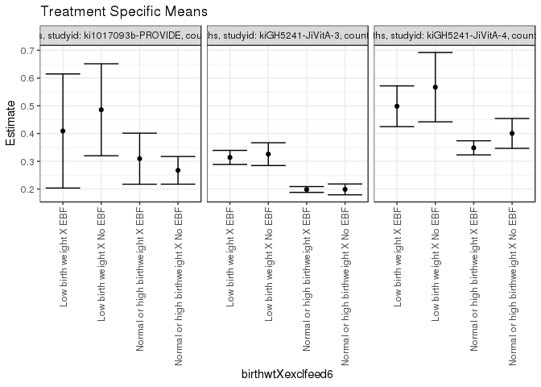

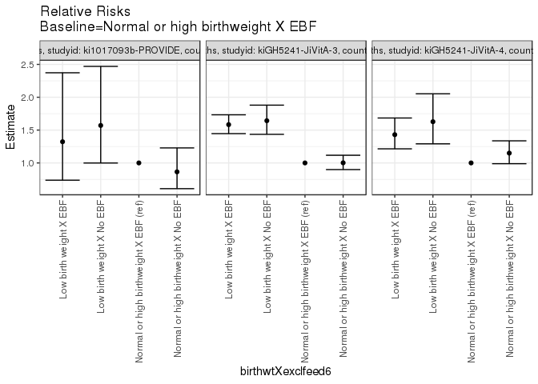

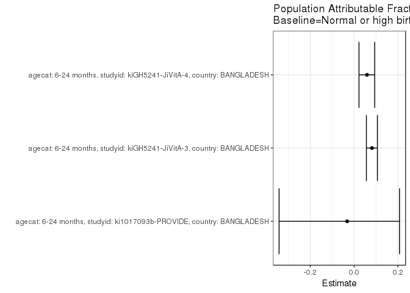

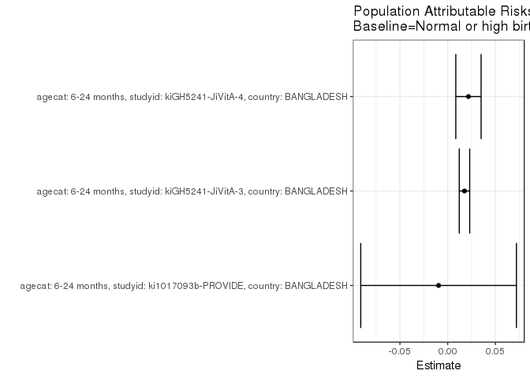

## Results Table

### Parameter: TSM

| agecat | studyid | country | intervention_level | baseline_level | estimate | ci_lower | ci_upper |
| --- | --- | --- | --- | --- | --- | --- | --- |
| 6-24 months | ki1017093b-PROVIDE | BANGLADESH | Normal or high birthweight X EBF | NA | 0.3092784 | 0.2171986 | 0.4013581 |
| 6-24 months | ki1017093b-PROVIDE | BANGLADESH | Low birth weight X EBF | NA | 0.4090909 | 0.2034154 | 0.6147665 |
| 6-24 months | ki1017093b-PROVIDE | BANGLADESH | Normal or high birthweight X No EBF | NA | 0.2673267 | 0.2174407 | 0.3172127 |
| 6-24 months | ki1017093b-PROVIDE | BANGLADESH | Low birth weight X No EBF | NA | 0.4857143 | 0.3199533 | 0.6514753 |
| 6-24 months | kiGH5241-JiVitA-3 | BANGLADESH | Normal or high birthweight X EBF | NA | 0.1982836 | 0.1878771 | 0.2086902 |
| 6-24 months | kiGH5241-JiVitA-3 | BANGLADESH | Low birth weight X EBF | NA | 0.3138863 | 0.2886027 | 0.3391700 |
| 6-24 months | kiGH5241-JiVitA-3 | BANGLADESH | Normal or high birthweight X No EBF | NA | 0.1986374 | 0.1790352 | 0.2182396 |
| 6-24 months | kiGH5241-JiVitA-3 | BANGLADESH | Low birth weight X No EBF | NA | 0.3256986 | 0.2845298 | 0.3668674 |
| 6-24 months | kiGH5241-JiVitA-4 | BANGLADESH | Normal or high birthweight X EBF | NA | 0.3484392 | 0.3230862 | 0.3737922 |
| 6-24 months | kiGH5241-JiVitA-4 | BANGLADESH | Low birth weight X EBF | NA | 0.4983589 | 0.4249840 | 0.5717338 |
| 6-24 months | kiGH5241-JiVitA-4 | BANGLADESH | Normal or high birthweight X No EBF | NA | 0.4004236 | 0.3464153 | 0.4544319 |
| 6-24 months | kiGH5241-JiVitA-4 | BANGLADESH | Low birth weight X No EBF | NA | 0.5671205 | 0.4421716 | 0.6920694 |

### Parameter: E(Y)

| agecat | studyid | country | intervention_level | baseline_level | estimate | ci_lower | ci_upper |
| --- | --- | --- | --- | --- | --- | --- | --- |
| 6-24 months | ki1017093b-PROVIDE | BANGLADESH | NA | NA | 0.2997812 | 0.2577294 | 0.3418330 |
| 6-24 months | kiGH5241-JiVitA-3 | BANGLADESH | NA | NA | 0.2158938 | 0.2063850 | 0.2254026 |
| 6-24 months | kiGH5241-JiVitA-4 | BANGLADESH | NA | NA | 0.3701979 | 0.3479106 | 0.3924853 |

### Parameter: RR

| agecat | studyid | country | intervention_level | baseline_level | estimate | ci_lower | ci_upper |
| --- | --- | --- | --- | --- | --- | --- | --- |
| 6-24 months | ki1017093b-PROVIDE | BANGLADESH | Normal or high birthweight X EBF | Normal or high birthweight X EBF | 1.0000000 | 1.0000000 | 1.000000 |
| 6-24 months | ki1017093b-PROVIDE | BANGLADESH | Low birth weight X EBF | Normal or high birthweight X EBF | 1.3227273 | 0.7374129 | 2.372629 |
| 6-24 months | ki1017093b-PROVIDE | BANGLADESH | Normal or high birthweight X No EBF | Normal or high birthweight X EBF | 0.8643564 | 0.6082656 | 1.228266 |
| 6-24 months | ki1017093b-PROVIDE | BANGLADESH | Low birth weight X No EBF | Normal or high birthweight X EBF | 1.5704762 | 0.9984926 | 2.470119 |
| 6-24 months | kiGH5241-JiVitA-3 | BANGLADESH | Normal or high birthweight X EBF | Normal or high birthweight X EBF | 1.0000000 | 1.0000000 | 1.000000 |
| 6-24 months | kiGH5241-JiVitA-3 | BANGLADESH | Low birth weight X EBF | Normal or high birthweight X EBF | 1.5830169 | 1.4462863 | 1.732674 |
| 6-24 months | kiGH5241-JiVitA-3 | BANGLADESH | Normal or high birthweight X No EBF | Normal or high birthweight X EBF | 1.0017842 | 0.8986041 | 1.116812 |
| 6-24 months | kiGH5241-JiVitA-3 | BANGLADESH | Low birth weight X No EBF | Normal or high birthweight X EBF | 1.6425895 | 1.4356167 | 1.879402 |
| 6-24 months | kiGH5241-JiVitA-4 | BANGLADESH | Normal or high birthweight X EBF | Normal or high birthweight X EBF | 1.0000000 | 1.0000000 | 1.000000 |
| 6-24 months | kiGH5241-JiVitA-4 | BANGLADESH | Low birth weight X EBF | Normal or high birthweight X EBF | 1.4302608 | 1.2146169 | 1.684190 |
| 6-24 months | kiGH5241-JiVitA-4 | BANGLADESH | Normal or high birthweight X No EBF | Normal or high birthweight X EBF | 1.1491922 | 0.9880647 | 1.336595 |
| 6-24 months | kiGH5241-JiVitA-4 | BANGLADESH | Low birth weight X No EBF | Normal or high birthweight X EBF | 1.6276023 | 1.2906898 | 2.052460 |

### Parameter: PAR

| agecat | studyid | country | intervention_level | baseline_level | estimate | ci_lower | ci_upper |
| --- | --- | --- | --- | --- | --- | --- | --- |
| 6-24 months | ki1017093b-PROVIDE | BANGLADESH | Normal or high birthweight X EBF | NA | -0.0094972 | -0.0910310 | 0.0720367 |
| 6-24 months | kiGH5241-JiVitA-3 | BANGLADESH | Normal or high birthweight X EBF | NA | 0.0176102 | 0.0121457 | 0.0230746 |
| 6-24 months | kiGH5241-JiVitA-4 | BANGLADESH | Normal or high birthweight X EBF | NA | 0.0217587 | 0.0085026 | 0.0350148 |

### Parameter: PAF

| agecat | studyid | country | intervention_level | baseline_level | estimate | ci_lower | ci_upper |
| --- | --- | --- | --- | --- | --- | --- | --- |
| 6-24 months | ki1017093b-PROVIDE | BANGLADESH | Normal or high birthweight X EBF | NA | -0.0316803 | -0.3428725 | 0.2073973 |
| 6-24 months | kiGH5241-JiVitA-3 | BANGLADESH | Normal or high birthweight X EBF | NA | 0.0815686 | 0.0560700 | 0.1063784 |
| 6-24 months | kiGH5241-JiVitA-4 | BANGLADESH | Normal or high birthweight X EBF | NA | 0.0587759 | 0.0222808 | 0.0939087 |